# 隐马尔科夫模型

## 概念介绍

**隐马尔可夫模型（Hidden Markov Model，HMM）** 是统计模型，它用来描述一个含有隐含未知参数的马尔可夫过程。其难点是从可观察的参数中确定该过程的隐含参数。

一个例子：〔盒子和球模型）假设有4个盒子，每个盒子里都装有红白两种颜 色的球，盒子里的红白球数由下表列出;

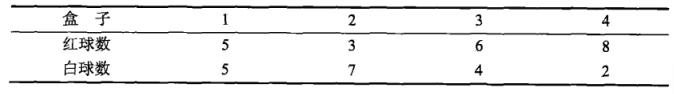

按照下面的方法抽球，产生一个球的颜色的观测序列:开始，从4个盒子里以等概率随机选取1个盒子，从这个盒子里随机抽出1个球，记录其颜色后，放回; 然后，从当前盒子随机转移到下--个盒子，规则是:如果当前盒子是盒子1，那么下一盒子一定是盒子2，如果当前是盒子2或3，那么分别以概率0.4和0.6转移到左边或右边的盒子，如果当前是盒子4，那么各以0.5的概率停留在盒子4或转移到盒子3;确定转移的盒子后，再从这个盒子里随机抽出1个球，记录其颜色，放回; 如此下去，重复进行5次，得到一个球的颜色的观测序列:

$$ O = \{红，红，白，白，红\} $$

在这个过程中，观察者只能观测到球的颜色的序列，观测不到球是从哪个盒子取出的，即观测不到盒子的序列. 在这个例子中有两个随机序列，一个是盒子的序列（**状态序列、隐含状态链、HMM中的马尔科夫链**，用I表示)，一个是球的颜色的观测序列（**观测序列、可见状态链**，用O表示)．前者是隐藏的，只有后者是可观测的．这是一个隐马尔可夫模型的例子，根据所给条件，可以明确状态集合、观测集合、序列长度以及模型的三要素.

盒子对应状态，状态的集合是

$$ I = \{盒子1, 盒子2, 盒子3, 盒子4\}，N=4 $$

球的颜色对应观测．观测的集合是

$$ V = \{红,白\}，M=2 $$

状态序列和观测序列长度T=5.

初始概率分布为

$$ \pi =(0.25,0.25,0.25,0.25)^T $$

观测概率分布为

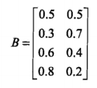

A、B、π属于隐马尔可夫模型的三个参数，隐马模型用λ(A,B,π)表示。

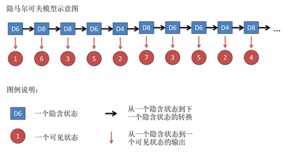

和HMM模型相关的算法主要分为三类，分别解决三种问题：

1）知道隐含状态数量、转换概率，根据可见状态链，想知道隐含状态链。——预测问题：维特比算法

应用于语音识别领域的解码问题、自然语言领域的词性标注和分词等问题。

2）知道隐含状态数量、转换概率，根据可见状态链，想知道得出可见状态链这个结果的概率。——概率计算问题：计算P(O|λ)，前向算法和后向算法

看似这个问题意义不大，因为的出来的结果很多时候都对应了一个比较大的概率。问这个问题的目的是检测观察到的结果和已知的模型是否吻合。如果很多次结果都对应了比较小的概率，那么就说明我们已知的模型很有可能是错的，有人偷偷把我们的骰子給换了。

3）知道隐含状态数量，不知道转换概率，观测到可见状态链，想反推出转换概率。——学习问题：监督算法和非监督算法（Baum-Welch算法）

这个问题很重要，因为这是最常见的情况。很多时候我们只有可见结果，不知道HMM模型里的参数，我们需要从可见结果估计出这些参数，这是建模的一个必要步骤。

## 概率计算问题

### 直接计算法

这是最直接的方法，即通过列举所有状态序列，计算每个状态序列与观测序列的联合概率P(O, I|λ)，然后对所有的状态序列求和。但是这个方法概念上可行但计算上计算量过大需要列举所有状态序列所有不可行。

### 前向算法

需要用到 **前向概率** 这一概念。前向概率就是在隐马尔可夫模型λ下，在某一时刻t的部分观测序列为$o_1到o_t和末尾状态为i_t$的联合概率。

$$ \alpha_t(i) = P(o_1,o_2,...,o_t, i_t | \lambda) $$

然后再使用前向概率计算观测序列概率，即根据前向概率从t = 1计算每个时刻t的概率，然后加在一起。其实就是递推。以下公式来自《统计学习方法》。

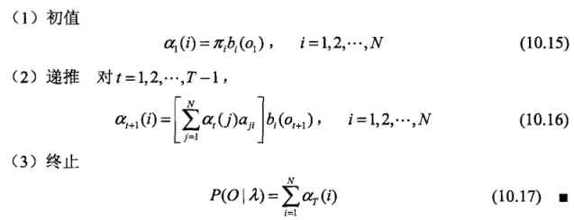

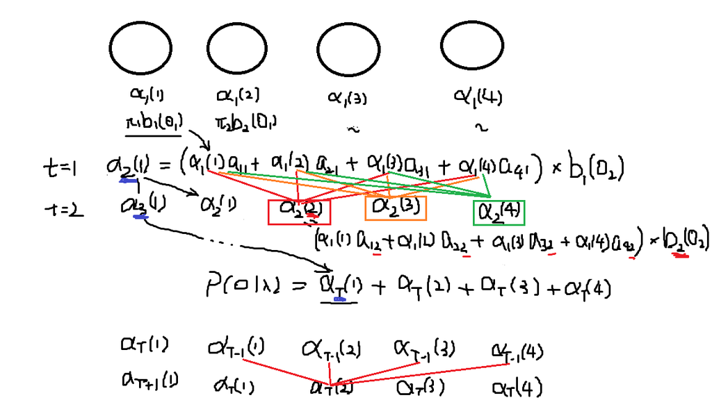

### 后向算法

与前向算法差别不大，只是后向算法需要用到后向概率：$λ和状态q_t下，t+1时刻的观测序列o_{t+1}到o_T的概率$。

## 预测问题

### 近似算法

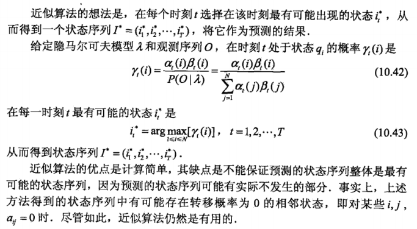

## 学习问题

### 监督学习算法

- 输入：一系列观测序列+对应的状态序列。输出：隐马尔科夫模型的三个参数A、B、π。
- 方法：使用极大似然估计（即样本频数）来得出。

$$ \hat{a}_{ij} = \frac{A_{ij}}{\sum_{j=1}^N A_{ij}} $$$$ \hat{b}_{j}(k) = \frac{b_{i}(k)}{\sum_{j=1}^N b_{i}(k)} $$$$ \hat{\pi}_{i}则通过样本中状态序列的初始状态来计算各种状态的频率 $$

监督学习算法要求训练数据同时包含观测序列和状态序列，需要人工标注，代价高，所以往往使用非监督学习算法，非监督学习算法只需要观测序列即可。

### 非监督学习算法 —— Baum-Welch算法

- 输入：一系列观测序列。输出：隐马尔科夫模型的三个参数A、B、π。
- 方法：EM算法

算法公式：目标是使得P(O|λ)最大化。 $$ P(O|\lambda) = \sum_I P(O|I,\lambda)P(I|\lambda) $$

**什么是EM算法？**

(参考：https://blog.csdn.net/v_july_v/article/details/81708386)

需要先了解什么是**极大似然估计**。用一个例子来简单说明：假设我们想了解一个学校男生或者女生的身高的分布θ（已知服从正态分布，参数是μ和$\sigma^2$），做法是从一个学校抽取100名男或女学生，抽到学生$A_1的概率是P(A_1|θ)$，抽到学生$A_2的概率是P(A_2|θ)$，以此类推，可以知道这一百个学生各自被抽到的概率。然后由于独立抽样，他们各自又是独立的，所以可以算出抽到这100个学生的总概率就是将这些概率累乘起来得到P(A|θ)。此时已经抽到了这100个学生，所以P(A|θ)最大化才可行，然后再对参数求导就可以得到参数的估计值了。

而**期望最大化算法（Expectation-maximization algorithm）**，是在概率模型中寻找参数最大似然估计或者最大后验估计的算法，其中概率模型依赖于无法观测的隐性变量。再利用上面的例子解释，就是我们先随机选是男还是女（但是我们不知道），然后再在其中抽取100名学生，这时就隐含了性别这一隐含变量，这样就不能直接求参数了，需要先知道性别才能继续求参数。

EM算法是通过以下两个步骤交替进行计算的：

- 第一步是计算期望（E），利用对隐藏变量的现有估计值（先初始化一个概率值，即是男生还是女生的概率），计算其最大似然估计值；
- 第二步是最大化（M），最大化在E步上求得的最大似然值来计算参数的值。M步上找到的参数估计值被用于下一个E步计算中，这个过程不断交替进行。

通过以上两个步骤的迭代就可以得到参数的值和隐含变量的真正的概率值。

公式推导：

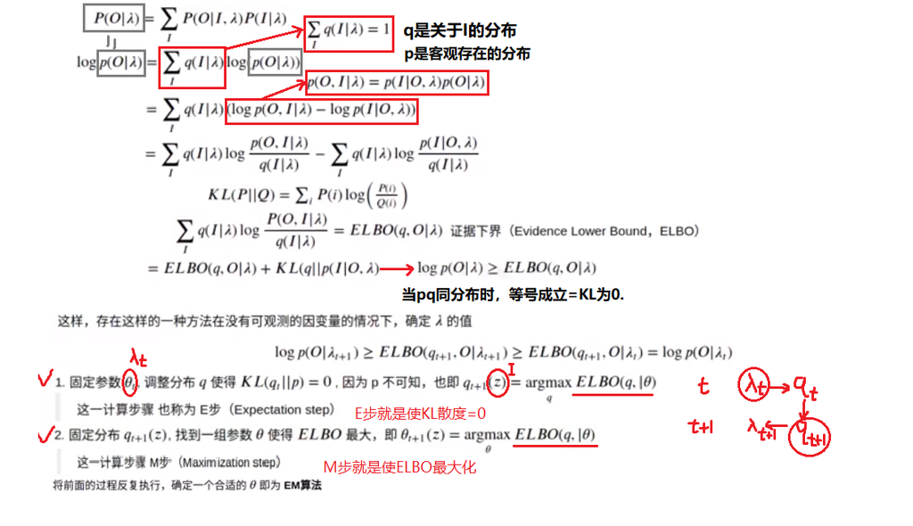

**Baum-Welch算法**

Baum-Welch算法就使用了EM算法的方法。